# Цифровой прорыв — 2020. ФИНАЛ // Кейс Минэнерго

## Разработка системы моделирования зависимости потребления электроэнергии и экономических показателей Российской Федерации по территориям и отраслям

`Big Data \\ Предиктивная аналитика`

# Постановка задачи

## Суть кейса

Понятие надежности электроснабжение - это основа функционирования как экономики, так и качества жизни в целом.

Возможность прогнозирования динамики потребления, возможность увязывания динамики потребления с экономическими показателями развития как регионов, так и отраслей, дает нам возможность более качественно планировать как ремонтные работы, так и другие программы, которые реализуются в рамках нашей отрасли.

Если мы сможем построить качественную, понятную, удобную, легкую модель, которая позволит нам не только прогнозировать, но и моделировать различные сценарии развития как потребления электроэнергии, так и экономических показателей, мы получим окно возможностей для повышения качества работы как нашей отрасли, так и системы в целом.

## Что ожидается от участников

1. Не зацикливаться на чем-то одном. Возможно, не привязываться только к экономическим показателям. Возможно, есть другие вещи на которые стоит обратить внимание.
2. Где-то выйти за границы, где-то выйти в целом за поставленную задачу.
3. Надо подойти к задаче как с точки зрения кода, так и с точки зрения визуализации решения.

## Что будет считаться решением кейса

1. Перечень экономических и других показателей, коррелирующих с динамикой потребления электроэнергии по территориям и отраслям.
2. Определение взаимного влияния потребления электроэнергии и собранных показателей на основе ретроспективных данных.
3. Модель прогнозирования динамики показателей экономического роста России по отраслям и территориям, исходя из динамики потребления электроэнергии.
4. Платформенное решение на базе существующих систем, позволяющее проводить моделирование и прогнозирование онлайн.

## Сценарий использования результата

- Данные о потреблении электроэнергии и другие данные по API поступают в аналитический центр Минэнерго России, предложенная платформа в рамках разработанной модели обращается за необходимыми данными, проводит расчёт и прогнозирование экономических показателей, предоставляет его результаты в базу данных, после чего они представляются на дашборд и визуализируются для принятия управленческих решений.

Пример зависимости: динамика потребления электроэнергии и объем промышленного производства, динамика потребительской активности, изменения оборотов бизнеса.

# Описание решения

## Вводная информация

1. На сайте Системного оператора Единой энергетической систем (ЕЭС) России представлена информация о почасовом потреблении электроэнергии в рамках объединенных энергетических систем (ОЭС) https://br.so-ups.ru/BR/GenConsum. Необходимо обеспечить автоматическое скачивание этой информации.
2. Надо выбрать социально-экономические и другие показатели по территориям и отраслям и проверить их на корреляцию с уровнем потребления электроэнергии. Эти показатели должны иметь регулярно обновляемые датасеты. Нужно обеспечить их автоматическую загрузку за период, сопоставимый с данными о потреблении электроэнергии.
3. Имея загруженные датасеты потребления электроэнергии и выбранных показателей, надо визуализировать зависимость между ними и смоделировать сценарии развития ситуации в будущем.

Примечания:

1. Важно учесть влияние сезонного и температурного факторов на потребление электроэнергии. Для этого необходимо загрузить информацию о дневной температуре по регионам.
2. Важно учесть влияние инфляции на показатели, имеющие денежное выражение. Для этого необходимо загрузить данные о ежемесячной инфляции.

## Структура хранения информации о потреблении электроэнергии

Для решения задачи вся информация должна быть структурирована с возможностью последующего масштабирования и с учетом использования базы данных.

**df_energy_db**:\ `index [int]` - номер записи\ `date_time [datetime]` - день и час регистрации потребления\ `period [str]` - периодичность регистрации показателя ('час')\ `sys_id_level [int]` - уровень учета - {0:'ЕЭС', 1:'ОЭС', 2:'Регион'}\ `power_sys_id [int]` - номер ОЭС или региона\ `unit_name [int]` - название учетной единицы (региона, ОЭС)\ `e_use_fact [float]` - объем потребления электроэнргии\ `dt_input [datetime]` - дата и время загрузки информации\ `source [str]` - источник загрузки

## Структура хранения социально-экономических и иных показателей

Необходимо структурировать информацию о социально-экономических показателях. Формат должен позволять легко добавлять новые показатели. В перспективе возможно использование базы данных.

**df_indicators_db**:\ `index [int]` - номер записи\ `indicator_name [str]` - название индикатора\ `unit_level [int]` - уровень учета - {0:'Россия', 1:'ОЭС', 2:'Регион'}\ `unit_name [int]` - название учетной единицы (региона, ОЭС)\ `power_sys_id [int]` - номер ОЭС или региона\ `date_time [datetime]` - точка времени в интервале, в котором рассчитан показатель\ `period [str]` - периодичность регистрации показателя ('час', 'месяц', 'год')\ `value [float]` - результат активности в виде набора шкал с ответами\ `moment [datetime]` - дата и время загрузки индикатора\ `source [str]` - источник данных информации о значении индикатора

_Комментарий: `power_sys_id [int]` рассчитывается отдельно в привязке к ОЭС. Важно, что могут быть загружены данные даже по одному показателю из разных источников за разные периоды._

## Алгоритм решения

# Импорт библиотек, настройки, служебные функции

```python
import os, wget

import numpy as np
import pandas as pd
import datetime as dt

pd.options.display.max_colwidth = 300

import matplotlib.pyplot as plt
import seaborn as sns

import re
import fitz
from tqdm import tqdm

from sklearn.model_selection import train_test_split
from sklearn.ensemble import RandomForestRegressor
from sklearn import metrics

RANDOM_SEED = 42

FILE_DATASET_E_USE_FACT = "Генерация и потребление_01.07.2010.csv"

# Словарь соответствий кодод ОЭС их названиям
oes_dict = {
    1019: 'ЕЭС России',
    530000: 'ОЭС Центра',
    540000: 'ОЭС Востока',
    550000: 'ОЭС Юга',
    600000: 'ОЭС Средней Волги',
    610000: 'ОЭС Сибири',
    630000: 'ОЭС Урала',
    840000: 'ОЭС Северо-Запада'
}

# Словарь принадлежности регионов ОЭС
dict_regions = {
    'Российская Федерация': 1019,
    'Центральный федеральный округ': 0,
    'Белгородская область': 530000,
    'Брянская область': 530000,
    'Владимирская область': 530000,
    'Воронежская область': 530000,
    'Ивановская область': 530000,
    'Калужская область': 530000,
    'Костромская область': 530000,
    'Курская область': 530000,
    'Липецкая область': 530000,
    'Московская область': 530000,
    'Орловская область': 530000,
    'Рязанская область': 530000,
    'Смоленская область': 530000,
    'Тамбовская область': 530000,
    'Тверская область': 530000,
    'Тульская область': 530000,
    'Ярославская область': 530000,
    'г.Москва': 530000,
    'Северо-Западный федеральный округ': 0,
    'Республика Карелия': 840000,
    'Республика Коми': 840000,
    'Архангельская область': 840000,
    'Вологодская область': 530000,
    'Калининградская область': 840000,
    'Ленинградская область': 840000,
    'Мурманская область': 840000,
    'Новгородская область': 840000,
    'Псковская область': 840000,
    'г.Санкт-Петербург': 840000,
    'Южный федеральный округ': 0,
    'Республика Адыгея': 550000,
    'Республика Калмыкия': 550000,
    'Республика Крым': 550000,
    'Краснодарский край': 550000,
    'Астраханская область': 550000,
    'Волгоградская область': 550000,
    'Ростовская область': 550000,
    'г. Севастополь': 550000,
    'Северо-Кавказский федеральный округ': 0,
    'Республика Дагестан': 550000,
    'Республика Ингушетия': 550000,
    'Кабардино-Балкарская Республика': 550000,
    'Карачаево-Черкесская Республика': 550000,
    'Республика Северная  Осетия - Алания': 550000,
    'Чеченская Республика': 550000,
    'Ставропольский край': 550000,
    'Приволжский федеральный округ': 0,
    'Республика Башкортостан': 630000,
    'Республика Марий Эл': 600000,
    'Республика Мордовия': 600000,
    'Республика Татарстан': 600000,
    'Удмуртская Республика': 630000,
    'Чувашская Республика': 600000,
    'Пермский край': 630000,
    'Кировская область': 630000,
    'Нижегородская область': 600000,
    'Оренбургская область': 630000,
    'Пензенская область': 600000,
    'Самарская область': 600000,
    'Саратовская область': 600000,
    'Ульяновская область': 600000,
    'Уральский федеральный округ': 0,
    'Курганская область': 630000,
    'Свердловская область': 630000,
    'Тюменская область': 630000,
    'Челябинская область': 630000,
    'Сибирский федеральный округ': 0,
    'Республика Алтай': 610000,
    'Республика Бурятия': 610000,
    'Республика Тыва': 610000,
    'Республика Хакасия': 610000,
    'Алтайский край': 610000,
    'Забайкальский край': 610000,
    'Красноярский край': 610000,
    'Иркутская область': 610000,
    'Кемеровская область': 610000,
    'Новосибирская область': 610000,
    'Омская область': 610000,
    'Томская область': 610000
}

# Функция для анализа содержимого датафреймов
def view_types(data, dropna=True):
    """
    Вывод отчета с анализом содержимого объекта data, подсчет представленных типов данных
    Parameters
    ----------
    data : DataFrame, Series, dict, list, другой тип, преобразуемый к DataFrame
        Объект DataFrame или приводимый к DataFrame для анализа
    dropna : bool, default True
        Не включать NaN в расчет количества уникальных значений
    Returns
    -------
    None
    2020 (c) Nikolay Ganibaev
    """
    from pandas import DataFrame
    data = DataFrame(data)
    columns_exch = {
        "<class 'str'>": 'str', "<class 'int'>": 'int', "<class 'float'>": 'float',
        "<class 'list'>": 'list', "<class 'dict'>": 'dict',
        "<class 'datetime.datetime'>": 'datetime',
        "<class 'pandas._libs.tslibs.timestamps.Timestamp'>": 'Timestamp',
    }
    df_output = pd.DataFrame(
        data[data[c].notna()][c].apply(type).value_counts() for c in data.columns
    ).fillna(0).astype(int)
    if data.isna().any().any():
        df_output['NaN'] = data.isna().sum()
    df_output['sum'] = df_output.sum(axis=1)
    df_output['(unique)'] = [data[c].astype(str).nunique(dropna) for c in data.columns]
    df_output.columns = [columns_exch.get(str(x), x) for x in df_output.columns]
    display(df_output.head(60))


# Функция расчета даты на начало следующего месяца для datetime
def next_month(d):
    return d.replace(d.year+1,1,1) if d.month == 12 else d.replace(month=d.month+1, day=1)

def load_indicator(INDICATOR, DIR_NAME, date_start=None):
    """
    Универсальная функция инкрементной загрузки значений индикаторов через API с сайта https://so-ups.ru/
    Parameters
    ----------
    INDICATOR: tuple
        (название индикатора, шаблон API-запроса, номер колонки со значением индикатора в csv-файле)
    DIR_NAME: str
        Код индикатора и имя директории для хранения csv-файлов
    date_start: str or datetime-like
        Дата периода загрузки индикатора, по умолчанию 2011-01-01
    Returns
    -------
    None
    2020 (c) Nikolay Ganibaev
    """
    if not os.path.isdir(DIR_NAME):
        os.mkdir(DIR_NAME)

    if date_start==None:
        date_start = dt.datetime(2011, 1, 1)

    # Загружаем по текущий момент
    date_end = next_month(dt.datetime.utcnow() + dt.timedelta(hours=+3))

    # Удаляем последние файлы в кэше
    cache_update = sorted(os.listdir(DIR_NAME))[-len(oes_dict):]

    for filename in cache_update:
        os.remove(f"{DIR_NAME}\\{filename}")

    for date_get in tqdm(pd.date_range(date_start, date_end, freq='M')):
        for ees_oes in oes_dict:
            csv_file = (f"https://so-ups.ru/index.php?id={DIR_NAME}&no_cache=1&tx_ms1cdu_pi1[kpo]={str(ees_oes)}&" +
                        f"tx_ms1cdu_pi1[dt]={date_get.strftime('%d.%m.%Y')}&tx_ms1cdu_pi1[format]=csv")

            if not f"{date_get.strftime('%Y-%m-%d')}_{INDICATOR[1]}_{str(ees_oes)}.csv" in os.listdir(DIR_NAME):
                wget.download(csv_file, DIR_NAME, None)
        date_get = (dt.datetime(date_get.year+1, 1, 1)
                    if date_get.month == 12
                    else date_get.replace(month=date_get.month+1, day=1))
        date_get = next_month(date_get)
```

# Загрузка данных

## СО ЕЭС | Генерация и потребление (почасовая, дашборд)

На сайте Системного оператора Единой энергетической системы (СО ЕЭС) России представлена информация о почасовом потреблении электроэнергии в рамках объединенных энергетических систем (ОЭС)

https://br.so-ups.ru/BR/GenConsum (дашборд)

Информация о потреблении электроэнергии на дашборде https://br.so-ups.ru/BR/GenConsum представлена только по первой синхронной зоне (не включена ОЭС Востока - вторая синхронная зона).

```python
# Предварительно загрузили информацию со страницы https://br.so-ups.ru/BR/GenConsum в каталог `input`

print(f"Загружаем датасет `{FILE_DATASET_E_USE_FACT}`.")
df_input = pd.read_csv(f"input\\{FILE_DATASET_E_USE_FACT}", sep=';')
print(f"В загруженном датасете {len(df_input)} записи.")
view_types(df_input)
df_input
```

```
Загружаем датасет `Генерация и потребление_01.07.2010.csv`.
В загруженном датасете 547776 записи.
```

|  | int | str | float | NaN | sum | (unique) |
| --- | --- | --- | --- | --- | --- | --- |
| INTERVAL | 547776 | 0 | 0 | 0 | 547776 | 24 |
| M_DATE | 0 | 547776 | 0 | 0 | 547776 | 3804 |
| PRICE_ZONE_ID | 547776 | 0 | 0 | 0 | 547776 | 2 |
| POWER_SYS_ID | 547776 | 0 | 0 | 0 | 547776 | 6 |
| E_USE_FACT | 0 | 0 | 547345 | 431 | 547776 | 29155 |

|  | INTERVAL | M_DATE | PRICE_ZONE_ID | POWER_SYS_ID | E_USE_FACT |
| --- | --- | --- | --- | --- | --- |
| 0 | 0 | 01.07.2010 0:00:00 | 1 | 530000 | 18684.0 |
| 1 | 1 | 01.07.2010 0:00:00 | 1 | 530000 | 17925.0 |
| 2 | 2 | 01.07.2010 0:00:00 | 1 | 530000 | 17406.0 |
| 3 | 3 | 01.07.2010 0:00:00 | 1 | 530000 | 16951.0 |
| 4 | 4 | 01.07.2010 0:00:00 | 1 | 530000 | 16758.0 |
| ... | ... | ... | ... | ... | ... |
| 547771 | 19 | 28.11.2020 0:00:00 | 1 | 840000 | 0.0 |
| 547772 | 20 | 28.11.2020 0:00:00 | 1 | 840000 | 0.0 |
| 547773 | 21 | 28.11.2020 0:00:00 | 1 | 840000 | 0.0 |
| 547774 | 22 | 28.11.2020 0:00:00 | 1 | 840000 | 0.0 |
| 547775 | 23 | 28.11.2020 0:00:00 | 1 | 840000 | 0.0 |

547776 rows × 5 columns

```python
now = dt.datetime.utcnow() + dt.timedelta(hours=+3)

df_energy_db = pd.DataFrame()
df_energy_db['date_time'] = pd.to_datetime(
    df_input.M_DATE.str.slice(0,-8), format='%d.%m.%Y')+pd.to_timedelta(df_input.INTERVAL.astype(str)+':59:59')
df_energy_db['period'] = 'час'
df_energy_db['sys_id_level'] = 1  # ОЭС
df_energy_db['power_sys_id'] = df_input.POWER_SYS_ID
df_energy_db['unit_name'] = df_input.POWER_SYS_ID.map(oes_dict)
df_energy_db['e_use_fact'] = df_input.E_USE_FACT
df_energy_db['dt_input'] = now
df_energy_db['source'] = 'https://br.so-ups.ru/BR/GenConsum'
```

```python
df_energy_db = df_energy_db[df_energy_db.date_time.between('2011-01','2020-11')]
view_types(df_energy_db)
df_energy_db
```

|  | Timestamp | str | int | float | NaN | sum | (unique) |
| --- | --- | --- | --- | --- | --- | --- | --- |
| date_time | 517248 | 0 | 0 | 0 | 0 | 517248 | 86208 |
| period | 0 | 517248 | 0 | 0 | 0 | 517248 | 1 |
| sys_id_level | 0 | 0 | 517248 | 0 | 0 | 517248 | 1 |
| power_sys_id | 0 | 0 | 517248 | 0 | 0 | 517248 | 6 |
| unit_name | 0 | 517248 | 0 | 0 | 0 | 517248 | 6 |
| e_use_fact | 0 | 0 | 0 | 516817 | 431 | 517248 | 29084 |
| dt_input | 517248 | 0 | 0 | 0 | 0 | 517248 | 1 |
| source | 0 | 517248 | 0 | 0 | 0 | 517248 | 1 |

|  | date_time | period | sys_id_level | power_sys_id | unit_name | e_use_fact | dt_input | source |
| --- | --- | --- | --- | --- | --- | --- | --- | --- |
| 4416 | 2011-01-01 00:59:59 | час | 1 | 530000 | ОЭС Центра | 25765.0 | 2020-11-29 08:49:47.804436 | https://br.so-ups.ru/BR/GenConsum |
| 4417 | 2011-01-01 01:59:59 | час | 1 | 530000 | ОЭС Центра | 25116.0 | 2020-11-29 08:49:47.804436 | https://br.so-ups.ru/BR/GenConsum |
| 4418 | 2011-01-01 02:59:59 | час | 1 | 530000 | ОЭС Центра | 24289.0 | 2020-11-29 08:49:47.804436 | https://br.so-ups.ru/BR/GenConsum |
| 4419 | 2011-01-01 03:59:59 | час | 1 | 530000 | ОЭС Центра | 23286.0 | 2020-11-29 08:49:47.804436 | https://br.so-ups.ru/BR/GenConsum |
| 4420 | 2011-01-01 04:59:59 | час | 1 | 530000 | ОЭС Центра | 23169.0 | 2020-11-29 08:49:47.804436 | https://br.so-ups.ru/BR/GenConsum |
| ... | ... | ... | ... | ... | ... | ... | ... | ... |
| 547099 | 2020-10-31 19:59:59 | час | 1 | 840000 | ОЭС Северо-Запада | 11636.0 | 2020-11-29 08:49:47.804436 | https://br.so-ups.ru/BR/GenConsum |
| 547100 | 2020-10-31 20:59:59 | час | 1 | 840000 | ОЭС Северо-Запада | 11488.0 | 2020-11-29 08:49:47.804436 | https://br.so-ups.ru/BR/GenConsum |
| 547101 | 2020-10-31 21:59:59 | час | 1 | 840000 | ОЭС Северо-Запада | 11269.0 | 2020-11-29 08:49:47.804436 | https://br.so-ups.ru/BR/GenConsum |
| 547102 | 2020-10-31 22:59:59 | час | 1 | 840000 | ОЭС Северо-Запада | 10834.0 | 2020-11-29 08:49:47.804436 | https://br.so-ups.ru/BR/GenConsum |
| 547103 | 2020-10-31 23:59:59 | час | 1 | 840000 | ОЭС Северо-Запада | 10502.0 | 2020-11-29 08:49:47.804436 | https://br.so-ups.ru/BR/GenConsum |

517248 rows × 8 columns

```python
df_energy_db_month = df_energy_db.assign(month=df_energy_db['date_time'].dt.strftime(
    '%Y-%m')).groupby(['month', 'unit_name']).e_use_fact.sum().reset_index()

df_energy_db_month
```

|  | month | unit_name | e_use_fact |
| --- | --- | --- | --- |
| 0 | 2011-01 | ОЭС Северо-Запада | 9135152.0 |
| 1 | 2011-01 | ОЭС Сибири | 21055742.0 |
| 2 | 2011-01 | ОЭС Средней Волги | 10136885.0 |
| 3 | 2011-01 | ОЭС Урала | 23966113.0 |
| 4 | 2011-01 | ОЭС Центра | 21279943.0 |
| ... | ... | ... | ... |
| 703 | 2020-10 | ОЭС Сибири | 17983466.0 |
| 704 | 2020-10 | ОЭС Средней Волги | 8915269.0 |
| 705 | 2020-10 | ОЭС Урала | 20652367.0 |
| 706 | 2020-10 | ОЭС Центра | 20311941.0 |
| 707 | 2020-10 | ОЭС Юга | 7783812.0 |

708 rows × 3 columns

## СО ЕЭС | Генерация и потребление (сутки, индикаторы)

https://so-ups.ru/index.php?id=ees_gen_consump_day (Деятельность / Индикаторы работы ЕЭС/ОЭС

Оперативные данные о выработке и потреблении электроэнергии в Единой энергетической системе (ЕЭС) России и объединенных энергетических системах (ОЭС) на каждые сутки

```python
# Скачиваем информацию о потреблении электроэнергии с сайта https://so-ups.ru/index.php?id=ees_gen_consump_day
# в каталог `ees_gen_consump_day`. Ранее скаченные csv-файлы кэшируются и не скачиваются повторно

INDICATOR = ('Потребление электроэнергии', '0_3', 2)
DIR_NAME = 'ees_gen_consump_day'

load_indicator(INDICATOR, DIR_NAME)
```

```python
print(f"Всего файлов со значениями показателя `{INDICATOR[0]}`: {len(os.listdir(DIR_NAME))}")
```

```
Всего файлов со значениями показателя `Потребление электроэнергии`: 952
```

```python
# Загружаем значения потребления электроэнергии на каждый день с 2011 года по всем ОЭС и по ЕЭС

df_e_use = pd.DataFrame()
for csv_file in tqdm(os.listdir(DIR_NAME)):
    if csv_file[-3:] == 'csv':
        df_e_use = df_e_use.append(
            pd.read_csv(f"{DIR_NAME}\\{csv_file}", sep=';', encoding='cp1251')
            .assign(power_sys_id=int(csv_file[:-4].split('_')[-1])),
            ignore_index=True).drop_duplicates()
df_e_use['date_time'] = pd.to_datetime(df_e_use.iloc[:, 0], format='%d-%m-%Y')
df_e_use['e_use'] = df_e_use.iloc[:, INDICATOR[2]]/1000
df_e_use = df_e_use[['date_time', 'power_sys_id', 'e_use']]
df_e_use['unit_name'] = df_e_use.power_sys_id.map(oes_dict)
```

```python
# Убедимся в корректности загрузки значений потребления электроэнергии
view_types(df_e_use)
df_e_use = df_e_use[df_e_use.date_time<'2020-10']
df_e_use.sort_values('date_time')

#  Убираем сумму по ЕЭС России в целом
df_e_use = df_e_use[df_e_use.unit_name != 'ЕЭС России'].reset_index(drop=True)
df_e_use
```

|  | Timestamp | int | float | str | sum | (unique) |
| --- | --- | --- | --- | --- | --- | --- |
| date_time | 28424 | 0 | 0 | 0 | 28424 | 3553 |
| power_sys_id | 0 | 28424 | 0 | 0 | 28424 | 8 |
| e_use | 0 | 0 | 28424 | 0 | 28424 | 27799 |
| unit_name | 0 | 0 | 0 | 28424 | 28424 | 8 |

|  | date_time | power_sys_id | e_use | unit_name |
| --- | --- | --- | --- | --- |
| 0 | 2011-01-01 | 530000 | 601.980 | ОЭС Центра |
| 1 | 2011-01-02 | 530000 | 602.258 | ОЭС Центра |
| 2 | 2011-01-03 | 530000 | 617.899 | ОЭС Центра |
| 3 | 2011-01-04 | 530000 | 646.364 | ОЭС Центра |
| 4 | 2011-01-05 | 530000 | 655.108 | ОЭС Центра |
| ... | ... | ... | ... | ... |
| 24446 | 2020-09-25 | 840000 | 236.440 | ОЭС Северо-Запада |
| 24447 | 2020-09-26 | 840000 | 230.124 | ОЭС Северо-Запада |
| 24448 | 2020-09-27 | 840000 | 225.529 | ОЭС Северо-Запада |
| 24449 | 2020-09-28 | 840000 | 234.053 | ОЭС Северо-Запада |
| 24450 | 2020-09-29 | 840000 | 237.180 | ОЭС Северо-Запада |

24451 rows × 4 columns

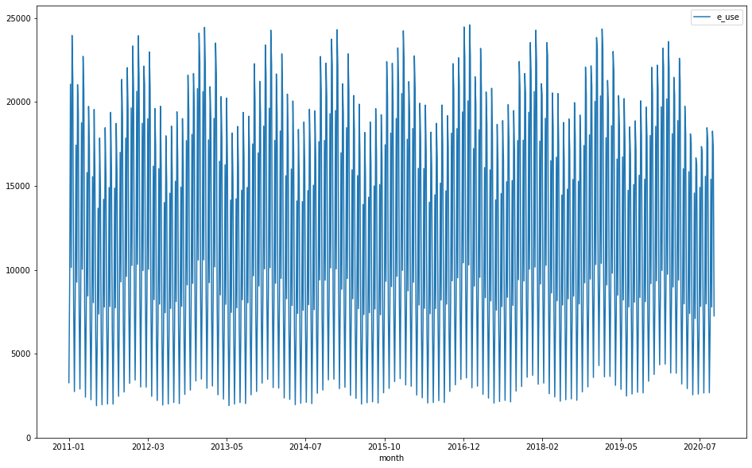

```python
df_e_use_month = df_e_use.assign(month=df_e_use['date_time'].dt.strftime(
    '%Y-%m')).groupby(['month', 'unit_name']).e_use.sum().reset_index()
df_e_use_month.plot(x='month', ylim=(0,None), figsize=(16,10))
```

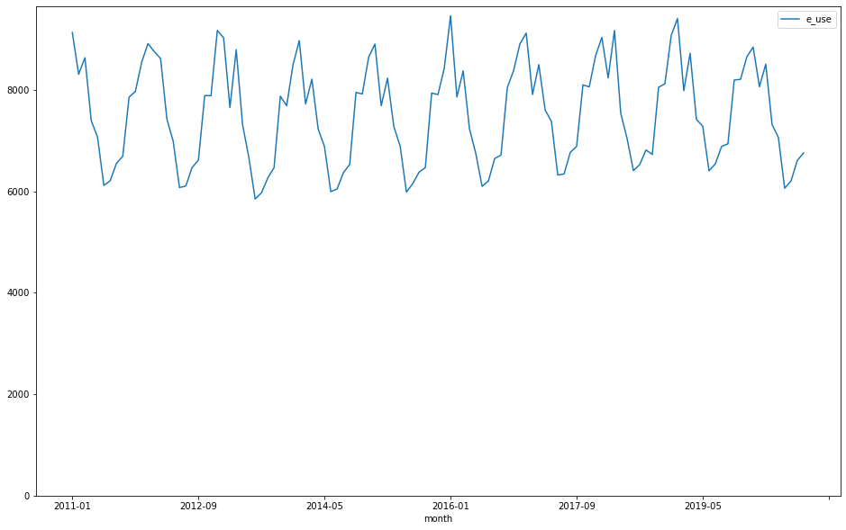

```python
# Выберем для работы одну ОЭС, например, 'ОЭС Северо-Запада'
df_e_use_month = df_e_use_month[df_e_use_month.unit_name == 'ОЭС Северо-Запада'].reset_index(drop=True)
df_e_use_month.plot(x='month', ylim=(0,None), figsize=(16,10))
```

## СО ЕЭС | Температура в ЕЭС России (сутки, индикаторы)

https://so-ups.ru/index.php?id=ees_temperature (Деятельность / Индикаторы работы ЕЭС/ОЭС)

Данные о средней температуре наружного воздуха в Единой энергетической системе (ЕЭС) России и объединенных энергетических системах (ОЭС) на каждые сутки

```python
# Скачиваем информацию о температуре с сайта https://so-ups.ru/index.php?id=ees_temperature
# в каталог `temperature`

INDICATOR = ('Температура', '0_0', 1)
DIR_NAME = 'ees_temperature'

load_indicator(INDICATOR, DIR_NAME)
```

```python
# Загружаем значения температуры на каждый день с 2011 года по всем ОЭС и по ЕЭС

df_temperatures = pd.DataFrame()
for csv_file in tqdm(os.listdir(DIR_NAME)):
    if csv_file[-3:] == 'csv':
        df_temperatures = df_temperatures.append(
            pd.read_csv(f"{DIR_NAME}\\{csv_file}", sep=';', encoding='cp1251')
            .assign(power_sys_id=int(csv_file[:-4].split('_')[-1])),
            ignore_index=True).drop_duplicates()
df_temperatures['date_time'] = pd.to_datetime(
    df_temperatures.iloc[:, 0], format='%d-%m-%Y')
df_temperatures['t'] = df_temperatures.iloc[:, INDICATOR[2]]
df_temperatures = df_temperatures[['date_time', 'power_sys_id', 't']]
df_temperatures['unit_name']= df_temperatures.power_sys_id.map(oes_dict)
```

```python
# Убедимся в корректности загрузки значений температуры
view_types(df_temperatures)
df_temperatures = df_temperatures[df_temperatures.date_time<'2020-10']
df_temperatures.sort_values('date_time')
df_temperatures
```

|  | Timestamp | int | float | str | sum | (unique) |
| --- | --- | --- | --- | --- | --- | --- |
| date_time | 28944 | 0 | 0 | 0 | 28944 | 3618 |
| power_sys_id | 0 | 28944 | 0 | 0 | 28944 | 8 |
| t | 0 | 0 | 28944 | 0 | 28944 | 5052 |
| unit_name | 0 | 0 | 0 | 28944 | 28944 | 8 |

|  | date_time | power_sys_id | t | unit_name |
| --- | --- | --- | --- | --- |
| 0 | 2011-01-01 | 1019 | -15.14 | ЕЭС России |
| 1 | 2011-01-02 | 1019 | -14.51 | ЕЭС России |
| 2 | 2011-01-03 | 1019 | -15.42 | ЕЭС России |
| 3 | 2011-01-04 | 1019 | -16.56 | ЕЭС России |
| 4 | 2011-01-05 | 1019 | -16.60 | ЕЭС России |
| ... | ... | ... | ... | ... |
| 28459 | 2020-09-26 | 840000 | 14.30 | ОЭС Северо-Запада |
| 28460 | 2020-09-27 | 840000 | 13.25 | ОЭС Северо-Запада |
| 28461 | 2020-09-28 | 840000 | 10.99 | ОЭС Северо-Запада |
| 28462 | 2020-09-29 | 840000 | 10.57 | ОЭС Северо-Запада |
| 28463 | 2020-09-30 | 840000 | 10.94 | ОЭС Северо-Запада |

28464 rows × 4 columns

```python
df_t_month = df_temperatures.assign(month=df_temperatures['date_time'].dt.strftime(
    '%Y-%m')).groupby(['month', 'unit_name']).t.agg(mean_t='mean', min_t='min', max_t='max').reset_index()
df_t_month = df_t_month[df_t_month.unit_name != 'ЕЭС России'].reset_index(drop=True)
df_t_month
```

|  | month | unit_name | mean_t | min_t | max_t |
| --- | --- | --- | --- | --- | --- |
| 0 | 2011-01 | ОЭС Востока | -19.680357 | -31.00 | -10.50 |
| 1 | 2011-01 | ОЭС Северо-Запада | -10.421429 | -20.30 | 0.80 |
| 2 | 2011-01 | ОЭС Сибири | -23.634643 | -33.00 | -12.25 |
| 3 | 2011-01 | ОЭС Средней Волги | -11.417857 | -21.10 | -5.50 |
| 4 | 2011-01 | ОЭС Урала | -15.957143 | -23.60 | -7.30 |
| ... | ... | ... | ... | ... | ... |
| 814 | 2020-09 | ОЭС Сибири | 10.335000 | 2.48 | 18.27 |
| 815 | 2020-09 | ОЭС Средней Волги | 13.088000 | 7.73 | 23.34 |
| 816 | 2020-09 | ОЭС Урала | 10.448333 | 6.44 | 18.01 |
| 817 | 2020-09 | ОЭС Центра | 13.962667 | 8.73 | 19.98 |
| 818 | 2020-09 | ОЭС Юга | 20.108333 | 14.71 | 25.40 |

819 rows × 5 columns

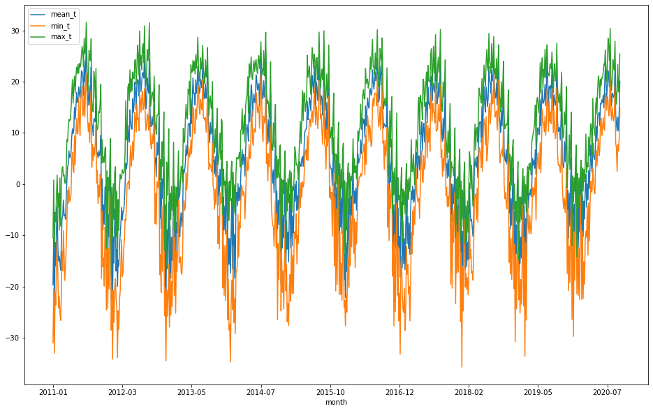

```python
df_t_month.plot(x='month', figsize=(16,10))
```

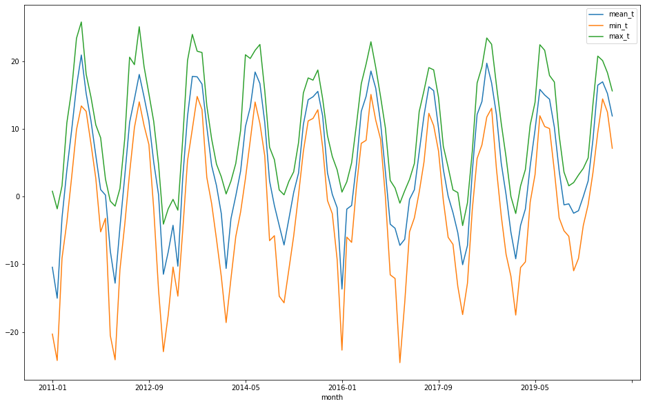

```python
# Выберем для работы одну ОЭС, например, 'ОЭС Северо-Запада'
df_t_month = df_t_month[df_t_month.unit_name == 'ОЭС Северо-Запада'].reset_index(drop=True)
df_t_month.plot(x='month', figsize=(16,10))
```

```python
# Проверяем на соответствие периодов и сортировки по ЕЭС/ОЭС
(df_e_use_month.month==df_t_month.month).all()&(df_e_use_month.unit_name==df_t_month.unit_name).all()
```

```
True
```

```python
# Формируем объединенную таблицу со всеми помесячными показателями
df = df_t_month.copy()
df['e_use_fact'] = df_e_use_month.e_use
df
```

|  | month | unit_name | mean_t | min_t | max_t | e_use_fact |
| --- | --- | --- | --- | --- | --- | --- |
| 0 | 2011-01 | ОЭС Северо-Запада | -10.421429 | -20.30 | 0.80 | 9135.035 |
| 1 | 2011-02 | ОЭС Северо-Запада | -15.003571 | -24.20 | -1.80 | 8312.657 |
| 2 | 2011-03 | ОЭС Северо-Запада | -3.122581 | -9.10 | 1.60 | 8639.082 |
| 3 | 2011-04 | ОЭС Северо-Запада | 3.890000 | -3.80 | 10.90 | 7398.265 |
| 4 | 2011-05 | ОЭС Северо-Запада | 9.845161 | 2.90 | 15.80 | 7069.549 |
| ... | ... | ... | ... | ... | ... | ... |
| 112 | 2020-05 | ОЭС Северо-Запада | 8.416452 | 3.55 | 13.68 | 7065.518 |
| 113 | 2020-06 | ОЭС Северо-Запада | 16.473333 | 9.50 | 20.76 | 6063.117 |
| 114 | 2020-07 | ОЭС Северо-Запада | 16.960000 | 14.44 | 20.10 | 6203.556 |
| 115 | 2020-08 | ОЭС Северо-Запада | 15.236452 | 12.49 | 18.31 | 6610.119 |
| 116 | 2020-09 | ОЭС Северо-Запада | 11.915333 | 7.15 | 15.62 | 6761.058 |

117 rows × 6 columns

## Росстат | Информация для ведения мониторинга социально-экономического положения субъектов Российской Федерации

https://rosstat.gov.ru/folder/11109/document/13259

Материал содержит важнейшие социально-экономические показатели по регионам России, формируемые Росстатом в соответствии с распоряжением Правительства Российской Федерации от 15 июня 2009г. №806-р для мониторинга процессов в реальном секторе экономики, финансово-банковской и социальной сферах субъектов Российской Федерации, а также другие статистические данные, характеризующие текущее социально-экономическое положение субъектов Российской Федерации: индексы промышленного производства, продукции сельского хозяйства, строительства, оборота розничной торговли, платных услуг населению, инвестиций в основной капитал, потребительских цен. Включены показатели, характеризующие финансовую деятельность организаций, просроченную задолженность по заработной плате, денежные доходы населения, а также данные о структуре занятости и ее динамике. Представленная информация позволяет оценивать ежемесячные изменения в экономике и социальной сфере субъектов Российской Федерации.

```python
print("Для анализа выбраны следующие показатели (приведены помесячно с 2011 года):")
filenames = os.listdir('rosstat-regions')
filenames
```

```
Для анализа выбраны следующие показатели (приведены помесячно с 2011 года):
```

```
['01-01 индекс промышленного производства.xlsx',
 '01-06 отгрузка товаров.xlsx',
 '01-11 производство электроэнергии.xlsx',
 '03-01 объем работ выполненных по ВЭД Строительство.xlsx',
 '05-01 оборот розничной торговли.xlsx',
 '09-01 цены на товары и услуги.xlsx',
 '09-06 фиксированный набор.xlsx',
 '12-01 среднемесячная заработная плата.xlsx',
 '~$03-01 объем работ выполненных по ВЭД Строительство.xlsx']
```

```python
month_dict = {
    'январь': '01',
    'февраль': '02',
    'март': '03',
    'апрель': '04',
    'май': '05',
    'июнь': '06',
    'июль': '07',
    'август': '08',
    'сентябрь': '09',
    'октябрь': '10',
    'ноябрь': '11',
    'декабрь': '12',
}
```

### Индекс промышленного производства

```python
df_input = (pd.read_excel(f"rosstat-regions\\{filenames[0]}", header=[0, 1], index_col=0)
            .reset_index()
            .rename(columns={'index': 'region'})
            .melt(id_vars='region', var_name=['year', 'n_month']))

df_input.value = df_input.value.replace({'…': 0})

df_input["indicator_name"]="Индекс промышленного производства"
df_input["id"]=df_input.region.map(dict_regions)
df_input["unit_name"]=df_input.id.map(oes_dict)
df_input["month"]='-'
df_input["month"]=df_input.year.str.slice(0,4)+df_input.month+df_input.n_month.str.strip().map(month_dict)

view_types(df_input)
df_input.dropna()
```

|  | str | float | int | NaN | sum | (unique) |
| --- | --- | --- | --- | --- | --- | --- |
| region | 9477 | 0 | 0 | 0 | 9477 | 81 |
| year | 9477 | 0 | 0 | 0 | 9477 | 10 |
| n_month | 9477 | 0 | 0 | 0 | 9477 | 13 |
| value | 0 | 9477 | 0 | 0 | 9477 | 898 |
| indicator_name | 9477 | 0 | 0 | 0 | 9477 | 1 |
| id | 0 | 0 | 9477 | 0 | 9477 | 8 |
| unit_name | 8658 | 0 | 0 | 819 | 9477 | 8 |
| month | 9477 | 0 | 0 | 0 | 9477 | 117 |

|  | region | year | n_month | value | indicator_name | id | unit_name | month |
| --- | --- | --- | --- | --- | --- | --- | --- | --- |
| 0 | Российская Федерация | 2011 год | январь | 84.7 | Индекс промышленного производства | 1019 | ЕЭС России | 2011-01 |
| 2 | Белгородская область | 2011 год | январь | 92.2 | Индекс промышленного производства | 530000 | ОЭС Центра | 2011-01 |
| 3 | Брянская область | 2011 год | январь | 78.5 | Индекс промышленного производства | 530000 | ОЭС Центра | 2011-01 |
| 4 | Владимирская область | 2011 год | январь | 76.4 | Индекс промышленного производства | 530000 | ОЭС Центра | 2011-01 |
| 5 | Воронежская область | 2011 год | январь | 74.8 | Индекс промышленного производства | 530000 | ОЭС Центра | 2011-01 |
| ... | ... | ... | ... | ... | ... | ... | ... | ... |
| 9472 | Иркутская область | 2020 год | сентябрь | 102.4 | Индекс промышленного производства | 610000 | ОЭС Сибири | 2020-09 |
| 9473 | Кемеровская область | 2020 год | сентябрь | 98.0 | Индекс промышленного производства | 610000 | ОЭС Сибири | 2020-09 |
| 9474 | Новосибирская область | 2020 год | сентябрь | 98.3 | Индекс промышленного производства | 610000 | ОЭС Сибири | 2020-09 |
| 9475 | Омская область | 2020 год | сентябрь | 104.9 | Индекс промышленного производства | 610000 | ОЭС Сибири | 2020-09 |
| 9476 | Томская область | 2020 год | сентябрь | 102.4 | Индекс промышленного производства | 610000 | ОЭС Сибири | 2020-09 |

8658 rows × 8 columns

```python
df_ipp_month = df_input.groupby(['month', 'unit_name']).value.agg(
    mean_ipp='mean', min_ipp='min', max_ipp='max').reset_index()
df_ipp_month
```

|  | month | unit_name | mean_ipp | min_ipp | max_ipp |
| --- | --- | --- | --- | --- | --- |
| 0 | 2011-01 | ЕЭС России | 84.700000 | 84.7 | 84.7 |
| 1 | 2011-01 | ОЭС Северо-Запада | 89.955556 | 78.1 | 118.2 |
| 2 | 2011-01 | ОЭС Сибири | 84.641667 | 61.6 | 96.8 |
| 3 | 2011-01 | ОЭС Средней Волги | 80.611111 | 66.9 | 94.2 |
| 4 | 2011-01 | ОЭС Урала | 89.611111 | 81.0 | 98.0 |
| ... | ... | ... | ... | ... | ... |
| 814 | 2020-09 | ОЭС Сибири | 101.975000 | 95.1 | 117.9 |
| 815 | 2020-09 | ОЭС Средней Волги | 107.711111 | 92.4 | 121.9 |
| 816 | 2020-09 | ОЭС Урала | 98.944444 | 81.4 | 105.5 |
| 817 | 2020-09 | ОЭС Центра | 104.584211 | 83.7 | 118.7 |
| 818 | 2020-09 | ОЭС Юга | 104.073333 | 87.2 | 139.0 |

819 rows × 5 columns

```python
# Выберем для работы одну ОЭС, например, 'ОЭС Северо-Запада'
df_ipp_month = df_ipp_month[df_ipp_month.unit_name =='ОЭС Северо-Запада'].reset_index(drop=True)
df_ipp_month
```

|  | month | unit_name | mean_ipp | min_ipp | max_ipp |
| --- | --- | --- | --- | --- | --- |
| 0 | 2011-01 | ОЭС Северо-Запада | 89.955556 | 78.1 | 118.2 |
| 1 | 2011-02 | ОЭС Северо-Запада | 102.822222 | 95.0 | 112.0 |
| 2 | 2011-03 | ОЭС Северо-Запада | 112.777778 | 94.4 | 125.9 |
| 3 | 2011-04 | ОЭС Северо-Запада | 93.822222 | 77.6 | 117.3 |
| 4 | 2011-05 | ОЭС Северо-Запада | 98.955556 | 95.5 | 109.6 |
| ... | ... | ... | ... | ... | ... |
| 112 | 2020-05 | ОЭС Северо-Запада | 96.488889 | 84.9 | 110.0 |
| 113 | 2020-06 | ОЭС Северо-Запада | 100.622222 | 90.1 | 109.7 |
| 114 | 2020-07 | ОЭС Северо-Запада | 105.377778 | 98.5 | 116.7 |
| 115 | 2020-08 | ОЭС Северо-Запада | 98.077778 | 91.8 | 102.7 |
| 116 | 2020-09 | ОЭС Северо-Запада | 103.244444 | 97.6 | 111.3 |

117 rows × 5 columns

```python
# Проверяем на соответствие периодов и сортировки по ЕЭС/ОЭС
(df.month==df_ipp_month.month).all()&(df.unit_name==df_ipp_month.unit_name).all()
```

```
True
```

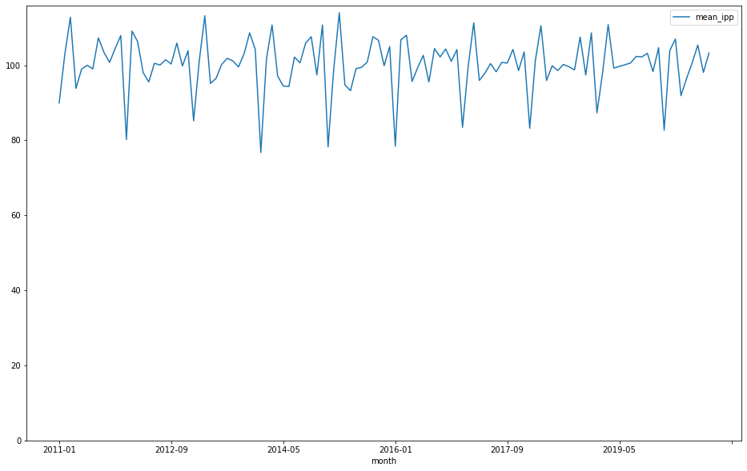

```python
df = df.join(df_ipp_month[['mean_ipp','min_ipp','max_ipp']])
df.plot(x='month', y='mean_ipp', ylim=(0,None), figsize=(16,10))
```

### Отгрузка товаров

```python
df_input = (pd.read_excel(f"rosstat-regions\\{filenames[1]}", header=[0, 1], index_col=0)
            .reset_index()
            .rename(columns={'index': 'region'})
            .melt(id_vars='region', var_name=['year', 'n_month']))

df_input.value = df_input.value.replace({'…': 0, '…6':0})

df_input["indicator_name"]="Отгрузка товаров"
df_input["id"]=df_input.region.map(dict_regions)
df_input["unit_name"]=df_input.id.map(oes_dict)
df_input["month"]='-'
df_input["month"]=df_input.year.str.slice(0,4)+df_input.month+df_input.n_month.str.strip().map(month_dict)

view_types(df_input)
df_input.dropna()
```

|  | str | float | int | NaN | sum | (unique) |
| --- | --- | --- | --- | --- | --- | --- |
| region | 9477 | 0 | 0 | 0 | 9477 | 81 |
| year | 9477 | 0 | 0 | 0 | 9477 | 10 |
| n_month | 9477 | 0 | 0 | 0 | 9477 | 13 |
| value | 0 | 9431 | 0 | 46 | 9477 | 9331 |
| indicator_name | 9477 | 0 | 0 | 0 | 9477 | 1 |
| id | 0 | 0 | 9477 | 0 | 9477 | 8 |
| unit_name | 8658 | 0 | 0 | 819 | 9477 | 8 |
| month | 9477 | 0 | 0 | 0 | 9477 | 117 |

|  | region | year | n_month | value | indicator_name | id | unit_name | month |
| --- | --- | --- | --- | --- | --- | --- | --- | --- |
| 0 | Российская Федерация | 2011 год | январь | 3.634340e+06 | Отгрузка товаров | 1019 | ЕЭС России | 2011-01 |
| 2 | Белгородская область | 2011 год | январь | 4.593802e+04 | Отгрузка товаров | 530000 | ОЭС Центра | 2011-01 |
| 3 | Брянская область | 2011 год | январь | 1.434540e+04 | Отгрузка товаров | 530000 | ОЭС Центра | 2011-01 |
| 4 | Владимирская область | 2011 год | январь | 2.277469e+04 | Отгрузка товаров | 530000 | ОЭС Центра | 2011-01 |
| 5 | Воронежская область | 2011 год | январь | 2.429828e+04 | Отгрузка товаров | 530000 | ОЭС Центра | 2011-01 |
| ... | ... | ... | ... | ... | ... | ... | ... | ... |
| 9472 | Иркутская область | 2020 год | сентябрь | 1.524145e+05 | Отгрузка товаров | 610000 | ОЭС Сибири | 2020-09 |
| 9473 | Кемеровская область | 2020 год | сентябрь | 1.594132e+05 | Отгрузка товаров | 610000 | ОЭС Сибири | 2020-09 |
| 9474 | Новосибирская область | 2020 год | сентябрь | 1.323671e+05 | Отгрузка товаров | 610000 | ОЭС Сибири | 2020-09 |
| 9475 | Омская область | 2020 год | сентябрь | 1.126168e+05 | Отгрузка товаров | 610000 | ОЭС Сибири | 2020-09 |
| 9476 | Томская область | 2020 год | сентябрь | 5.319686e+04 | Отгрузка товаров | 610000 | ОЭС Сибири | 2020-09 |

8612 rows × 8 columns

```python
df_otgruzka_month = df_input.groupby(['month', 'unit_name']).value.agg(
    otrg_tov='sum').reset_index()
df_otgruzka_month.otrg_tov = df_otgruzka_month.otrg_tov/1000
df_otgruzka_month
```

|  | month | unit_name | otrg_tov |
| --- | --- | --- | --- |
| 0 | 2011-01 | ЕЭС России | 3634.339936 |
| 1 | 2011-01 | ОЭС Северо-Запада | 391.024595 |
| 2 | 2011-01 | ОЭС Сибири | 407.505486 |
| 3 | 2011-01 | ОЭС Средней Волги | 374.190805 |
| 4 | 2011-01 | ОЭС Урала | 932.659473 |
| ... | ... | ... | ... |
| 814 | 2020-09 | ОЭС Сибири | 993.182547 |
| 815 | 2020-09 | ОЭС Средней Волги | 976.134781 |
| 816 | 2020-09 | ОЭС Урала | 1885.545679 |
| 817 | 2020-09 | ОЭС Центра | 3392.268944 |
| 818 | 2020-09 | ОЭС Юга | 763.239736 |

819 rows × 3 columns

```python
# Выберем для работы одну ОЭС, например, 'ОЭС Северо-Запада'
df_otgruzka_month = df_otgruzka_month[df_otgruzka_month.unit_name =='ОЭС Северо-Запада'].reset_index(drop=True)
df_otgruzka_month
```

|  | month | unit_name | otrg_tov |
| --- | --- | --- | --- |
| 0 | 2011-01 | ОЭС Северо-Запада | 391.024595 |
| 1 | 2011-02 | ОЭС Северо-Запада | 404.143697 |
| 2 | 2011-03 | ОЭС Северо-Запада | 453.967205 |
| 3 | 2011-04 | ОЭС Северо-Запада | 481.740745 |
| 4 | 2011-05 | ОЭС Северо-Запада | 463.582821 |
| ... | ... | ... | ... |
| 112 | 2020-05 | ОЭС Северо-Запада | 776.241683 |
| 113 | 2020-06 | ОЭС Северо-Запада | 911.935315 |
| 114 | 2020-07 | ОЭС Северо-Запада | 937.143033 |
| 115 | 2020-08 | ОЭС Северо-Запада | 1004.023283 |
| 116 | 2020-09 | ОЭС Северо-Запада | 1096.733719 |

117 rows × 3 columns

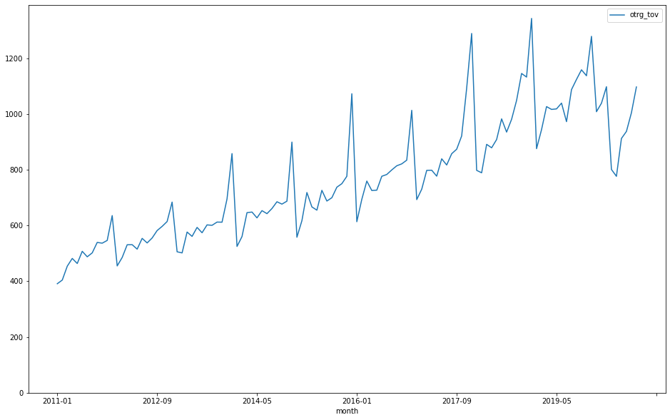

```python
df = df.join(df_otgruzka_month[['otrg_tov']])
df.plot(x='month', y='otrg_tov', ylim=(0,None), figsize=(16,10))
```

### Объем работ выполненных по ВЭД Строительство

```python
df_input = (pd.read_excel(f"rosstat-regions\\{filenames[3]}", header=[0, 1], index_col=0)
            .reset_index()
            .rename(columns={'index': 'region'})
            .melt(id_vars='region', var_name=['year', 'n_month']))

df_input.value = df_input.value.replace({'…': 0, '-':0})

df_input["indicator_name"]="Отгрузка товаров"
df_input["id"]=df_input.region.map(dict_regions)
df_input["unit_name"]=df_input.id.map(oes_dict)
df_input["month"]='-'
df_input["month"]=df_input.year.str.slice(0,4)+df_input.month+df_input.n_month.str.strip().map(month_dict)

view_types(df_input)
df_input.dropna()
```

|  | str | float | int | NaN | sum | (unique) |
| --- | --- | --- | --- | --- | --- | --- |
| region | 9477 | 0 | 0 | 0 | 9477 | 81 |
| year | 9477 | 0 | 0 | 0 | 9477 | 10 |
| n_month | 9477 | 0 | 0 | 0 | 9477 | 13 |
| value | 0 | 9431 | 0 | 46 | 9477 | 9302 |
| indicator_name | 9477 | 0 | 0 | 0 | 9477 | 1 |
| id | 0 | 0 | 9477 | 0 | 9477 | 8 |
| unit_name | 8658 | 0 | 0 | 819 | 9477 | 8 |
| month | 9477 | 0 | 0 | 0 | 9477 | 117 |

|  | region | year | n_month | value | indicator_name | id | unit_name | month |
| --- | --- | --- | --- | --- | --- | --- | --- | --- |
| 0 | Российская Федерация | 2011 год | январь | 201257.5000 | Отгрузка товаров | 1019 | ЕЭС России | 2011-01 |
| 2 | Белгородская область | 2011 год | январь | 3648.2000 | Отгрузка товаров | 530000 | ОЭС Центра | 2011-01 |
| 3 | Брянская область | 2011 год | январь | 520.0000 | Отгрузка товаров | 530000 | ОЭС Центра | 2011-01 |
| 4 | Владимирская область | 2011 год | январь | 576.2000 | Отгрузка товаров | 530000 | ОЭС Центра | 2011-01 |
| 5 | Воронежская область | 2011 год | январь | 1082.3000 | Отгрузка товаров | 530000 | ОЭС Центра | 2011-01 |
| ... | ... | ... | ... | ... | ... | ... | ... | ... |
| 9472 | Иркутская область | 2020 год | сентябрь | 92538.0102 | Отгрузка товаров | 610000 | ОЭС Сибири | 2020-09 |
| 9473 | Кемеровская область | 2020 год | сентябрь | 98019.7521 | Отгрузка товаров | 610000 | ОЭС Сибири | 2020-09 |
| 9474 | Новосибирская область | 2020 год | сентябрь | 72420.4349 | Отгрузка товаров | 610000 | ОЭС Сибири | 2020-09 |
| 9475 | Омская область | 2020 год | сентябрь | 74125.6793 | Отгрузка товаров | 610000 | ОЭС Сибири | 2020-09 |
| 9476 | Томская область | 2020 год | сентябрь | 48175.7169 | Отгрузка товаров | 610000 | ОЭС Сибири | 2020-09 |

8612 rows × 8 columns

```python
df_stroit_month = df_input.groupby(['month', 'unit_name']).value.agg(
    stroit='sum').reset_index()
df_stroit_month.stroit = df_stroit_month.stroit/1000
df_stroit_month
```

|  | month | unit_name | stroit |
| --- | --- | --- | --- |
| 0 | 2011-01 | ЕЭС России | 201.257500 |
| 1 | 2011-01 | ОЭС Северо-Запада | 19.340700 |
| 2 | 2011-01 | ОЭС Сибири | 15.244900 |
| 3 | 2011-01 | ОЭС Средней Волги | 20.276900 |
| 4 | 2011-01 | ОЭС Урала | 32.405000 |
| ... | ... | ... | ... |
| 814 | 2020-09 | ОЭС Сибири | 559.599451 |
| 815 | 2020-09 | ОЭС Средней Волги | 610.109333 |
| 816 | 2020-09 | ОЭС Урала | 1431.550784 |
| 817 | 2020-09 | ОЭС Центра | 1769.109597 |
| 818 | 2020-09 | ОЭС Юга | 724.577279 |

819 rows × 3 columns

```python
# Выберем для работы одну ОЭС, например, 'ОЭС Северо-Запада'
df_stroit_month = df_stroit_month[df_stroit_month.unit_name =='ОЭС Северо-Запада'].reset_index(drop=True)
df_stroit_month
```

|  | month | unit_name | stroit |
| --- | --- | --- | --- |
| 0 | 2011-01 | ОЭС Северо-Запада | 19.340700 |
| 1 | 2011-02 | ОЭС Северо-Запада | 45.927300 |
| 2 | 2011-03 | ОЭС Северо-Запада | 81.311400 |
| 3 | 2011-04 | ОЭС Северо-Запада | 124.380400 |
| 4 | 2011-05 | ОЭС Северо-Запада | 166.347600 |
| ... | ... | ... | ... |
| 112 | 2020-05 | ОЭС Северо-Запада | 331.579571 |
| 113 | 2020-06 | ОЭС Северо-Запада | 414.861900 |
| 114 | 2020-07 | ОЭС Северо-Запада | 512.288055 |
| 115 | 2020-08 | ОЭС Северо-Запада | 596.506673 |
| 116 | 2020-09 | ОЭС Северо-Запада | 691.257008 |

117 rows × 3 columns

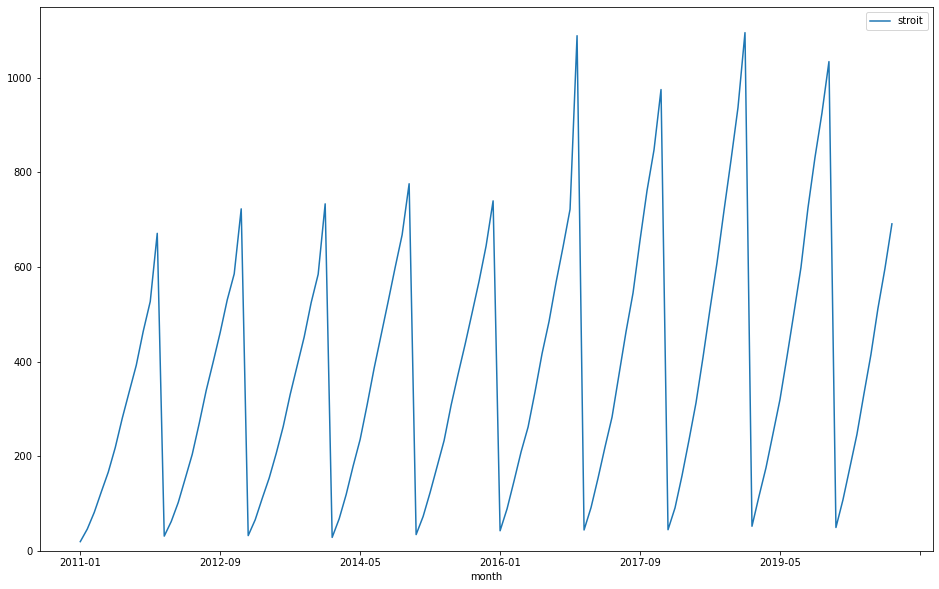

```python
df = df.join(df_stroit_month[['stroit']])
df.plot(x='month', y='stroit', ylim=(0,None), figsize=(16,10))
```

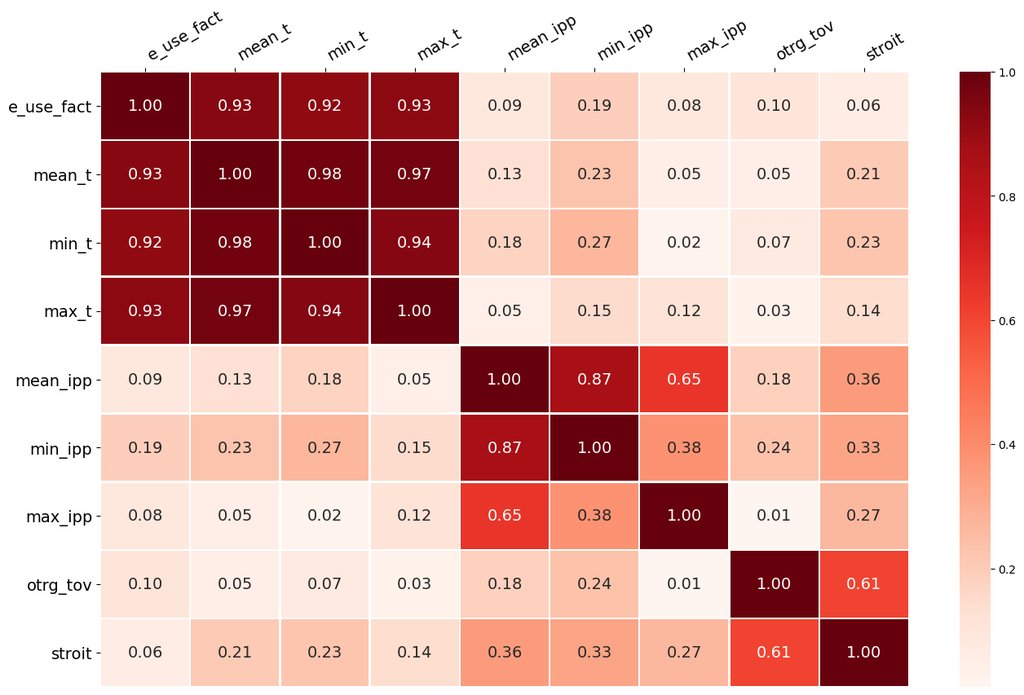

```python
key_param = 'e_use_fact'

plt.rcParams['xtick.top'] = plt.rcParams['xtick.labeltop'] = True
plt.rcParams['xtick.bottom'] = plt.rcParams['xtick.labelbottom'] = False

plt.figure(figsize=(16,10), dpi= 100)
df_corr = df[[key_param]+[c for c in df.columns if not c in [key_param]]].corr()
sns.heatmap(df_corr.abs(), annot=True, fmt='.2f', annot_kws={'fontsize':14}, cmap='Reds', linewidths=1)
#, mask=np.triu(df_corr)) colors — https://matplotlib.org/examples/color/colormaps_reference.html
plt.xticks(horizontalalignment='left', fontweight='light', fontsize=14, rotation=30)
plt.yticks(fontweight='light', fontsize=14, rotation=0);
```

# Прогнозная модель

## Прогноз потребления электроэнергии

```python
df
```

|  | month | unit_name | mean_t | min_t | max_t | e_use_fact | mean_ipp | min_ipp | max_ipp | otrg_tov | stroit |
| --- | --- | --- | --- | --- | --- | --- | --- | --- | --- | --- | --- |
| 0 | 2011-01 | ОЭС Северо-Запада | -10.421429 | -20.30 | 0.80 | 9135.035 | 89.955556 | 78.1 | 118.2 | 391.024595 | 19.340700 |
| 1 | 2011-02 | ОЭС Северо-Запада | -15.003571 | -24.20 | -1.80 | 8312.657 | 102.822222 | 95.0 | 112.0 | 404.143697 | 45.927300 |
| 2 | 2011-03 | ОЭС Северо-Запада | -3.122581 | -9.10 | 1.60 | 8639.082 | 112.777778 | 94.4 | 125.9 | 453.967205 | 81.311400 |
| 3 | 2011-04 | ОЭС Северо-Запада | 3.890000 | -3.80 | 10.90 | 7398.265 | 93.822222 | 77.6 | 117.3 | 481.740745 | 124.380400 |
| 4 | 2011-05 | ОЭС Северо-Запада | 9.845161 | 2.90 | 15.80 | 7069.549 | 98.955556 | 95.5 | 109.6 | 463.582821 | 166.347600 |
| ... | ... | ... | ... | ... | ... | ... | ... | ... | ... | ... | ... |
| 112 | 2020-05 | ОЭС Северо-Запада | 8.416452 | 3.55 | 13.68 | 7065.518 | 96.488889 | 84.9 | 110.0 | 776.241683 | 331.579571 |
| 113 | 2020-06 | ОЭС Северо-Запада | 16.473333 | 9.50 | 20.76 | 6063.117 | 100.622222 | 90.1 | 109.7 | 911.935315 | 414.861900 |
| 114 | 2020-07 | ОЭС Северо-Запада | 16.960000 | 14.44 | 20.10 | 6203.556 | 105.377778 | 98.5 | 116.7 | 937.143033 | 512.288055 |
| 115 | 2020-08 | ОЭС Северо-Запада | 15.236452 | 12.49 | 18.31 | 6610.119 | 98.077778 | 91.8 | 102.7 | 1004.023283 | 596.506673 |
| 116 | 2020-09 | ОЭС Северо-Запада | 11.915333 | 7.15 | 15.62 | 6761.058 | 103.244444 | 97.6 | 111.3 | 1096.733719 | 691.257008 |

117 rows × 11 columns

```python
# Разбиваем набор данных на тренировочный и тестовый
y = df['e_use_fact'].values
X = df[['mean_t', 'min_t','max_t','mean_ipp','min_ipp','max_ipp','otrg_tov','stroit']]
X
```

|  | mean_t | min_t | max_t | mean_ipp | min_ipp | max_ipp | otrg_tov | stroit |
| --- | --- | --- | --- | --- | --- | --- | --- | --- |
| 0 | -10.421429 | -20.30 | 0.80 | 89.955556 | 78.1 | 118.2 | 391.024595 | 19.340700 |
| 1 | -15.003571 | -24.20 | -1.80 | 102.822222 | 95.0 | 112.0 | 404.143697 | 45.927300 |
| 2 | -3.122581 | -9.10 | 1.60 | 112.777778 | 94.4 | 125.9 | 453.967205 | 81.311400 |
| 3 | 3.890000 | -3.80 | 10.90 | 93.822222 | 77.6 | 117.3 | 481.740745 | 124.380400 |
| 4 | 9.845161 | 2.90 | 15.80 | 98.955556 | 95.5 | 109.6 | 463.582821 | 166.347600 |
| ... | ... | ... | ... | ... | ... | ... | ... | ... |
| 112 | 8.416452 | 3.55 | 13.68 | 96.488889 | 84.9 | 110.0 | 776.241683 | 331.579571 |
| 113 | 16.473333 | 9.50 | 20.76 | 100.622222 | 90.1 | 109.7 | 911.935315 | 414.861900 |
| 114 | 16.960000 | 14.44 | 20.10 | 105.377778 | 98.5 | 116.7 | 937.143033 | 512.288055 |
| 115 | 15.236452 | 12.49 | 18.31 | 98.077778 | 91.8 | 102.7 | 1004.023283 | 596.506673 |
| 116 | 11.915333 | 7.15 | 15.62 | 103.244444 | 97.6 | 111.3 | 1096.733719 | 691.257008 |

117 rows × 8 columns

```python
size_train = int(len(X)*0.1)

X_train = X.iloc[:-size_train]
X_test = X.iloc[size_train:]
y_train = y[:-size_train]
y_test = y[size_train:]

# Создаём модель, используя метод Random forest
model = RandomForestRegressor(n_estimators=100, verbose=1, n_jobs=-1, random_state=RANDOM_SEED)

# Обучаем модель на тестовом наборе данных
model.fit(X_train, y_train)

# Используем обученную модель для предсказания рейтинга ресторанов в тестовой выборке.
# Предсказанные значения записываем в переменную y_pred
y_pred = model.predict(X_test)
```

```
[Parallel(n_jobs=-1)]: Using backend ThreadingBackend with 8 concurrent workers.
[Parallel(n_jobs=-1)]: Done  34 tasks      | elapsed:    0.0s
[Parallel(n_jobs=-1)]: Done 100 out of 100 | elapsed:    0.2s finished
[Parallel(n_jobs=8)]: Using backend ThreadingBackend with 8 concurrent workers.
[Parallel(n_jobs=8)]: Done  34 tasks      | elapsed:    0.0s
[Parallel(n_jobs=8)]: Done 100 out of 100 | elapsed:    0.0s finished
```

```python
mae = metrics.mean_absolute_error(y_test,y_pred)
mean = df['e_use_fact'].mean()
mae_percent = mae/mean

print('среднее уровень потребления электроэнергии в прогнозируемом интервале:', mean)
print('средняя ошибка прогноза: ', mae)
print('средняя ошибка:', mae_percent*100, '%')
```

```
среднее уровень потребления электроэнергии в прогнозируемом интервале: 7518.672658119659
средняя ошибка прогноза:  98.18118669811335
средняя ошибка: 1.3058313769264087 %
```

## Прогноз экономических показателей

```python
df
```

|  | month | unit_name | mean_t | min_t | max_t | e_use_fact | mean_ipp | min_ipp | max_ipp | otrg_tov | stroit |
| --- | --- | --- | --- | --- | --- | --- | --- | --- | --- | --- | --- |
| 0 | 2011-01 | ОЭС Северо-Запада | -10.421429 | -20.30 | 0.80 | 9135.035 | 89.955556 | 78.1 | 118.2 | 391.024595 | 19.340700 |
| 1 | 2011-02 | ОЭС Северо-Запада | -15.003571 | -24.20 | -1.80 | 8312.657 | 102.822222 | 95.0 | 112.0 | 404.143697 | 45.927300 |
| 2 | 2011-03 | ОЭС Северо-Запада | -3.122581 | -9.10 | 1.60 | 8639.082 | 112.777778 | 94.4 | 125.9 | 453.967205 | 81.311400 |
| 3 | 2011-04 | ОЭС Северо-Запада | 3.890000 | -3.80 | 10.90 | 7398.265 | 93.822222 | 77.6 | 117.3 | 481.740745 | 124.380400 |
| 4 | 2011-05 | ОЭС Северо-Запада | 9.845161 | 2.90 | 15.80 | 7069.549 | 98.955556 | 95.5 | 109.6 | 463.582821 | 166.347600 |
| ... | ... | ... | ... | ... | ... | ... | ... | ... | ... | ... | ... |
| 112 | 2020-05 | ОЭС Северо-Запада | 8.416452 | 3.55 | 13.68 | 7065.518 | 96.488889 | 84.9 | 110.0 | 776.241683 | 331.579571 |
| 113 | 2020-06 | ОЭС Северо-Запада | 16.473333 | 9.50 | 20.76 | 6063.117 | 100.622222 | 90.1 | 109.7 | 911.935315 | 414.861900 |
| 114 | 2020-07 | ОЭС Северо-Запада | 16.960000 | 14.44 | 20.10 | 6203.556 | 105.377778 | 98.5 | 116.7 | 937.143033 | 512.288055 |
| 115 | 2020-08 | ОЭС Северо-Запада | 15.236452 | 12.49 | 18.31 | 6610.119 | 98.077778 | 91.8 | 102.7 | 1004.023283 | 596.506673 |
| 116 | 2020-09 | ОЭС Северо-Запада | 11.915333 | 7.15 | 15.62 | 6761.058 | 103.244444 | 97.6 | 111.3 | 1096.733719 | 691.257008 |

117 rows × 11 columns

```python
# Прогнозируем индекс промпроизводства

# Разбиваем набор данных на тренировочный и тестовый
y = df['mean_ipp'].values
X = df[['e_use_fact']]

size_train = int(len(X)*0.1)

X_train = X.iloc[:-size_train]
X_test = X.iloc[size_train:]
y_train = y[:-size_train]
y_test = y[size_train:]

# Создаём модель, используя метод Random forest
model = RandomForestRegressor(n_estimators=100, verbose=1, n_jobs=-1, random_state=RANDOM_SEED)

# Обучаем модель на тестовом наборе данных
model.fit(X_train, y_train)

# Используем обученную модель для предсказания рейтинга ресторанов в тестовой выборке.
# Предсказанные значения записываем в переменную y_pred
y_pred = model.predict(X_test)
```

```
[Parallel(n_jobs=-1)]: Using backend ThreadingBackend with 8 concurrent workers.
[Parallel(n_jobs=-1)]: Done  34 tasks      | elapsed:    0.0s
[Parallel(n_jobs=-1)]: Done 100 out of 100 | elapsed:    0.0s finished
[Parallel(n_jobs=8)]: Using backend ThreadingBackend with 8 concurrent workers.
[Parallel(n_jobs=8)]: Done  34 tasks      | elapsed:    0.0s
[Parallel(n_jobs=8)]: Done 100 out of 100 | elapsed:    0.0s finished
```

```python
mae = metrics.mean_absolute_error(y_test,y_pred)
mean = df['mean_ipp'].mean()
mae_percent = mae/mean

print('среднее уровень потребления электроэнергии в прогнозируемом интервале:', mean)
print('средняя ошибка прогноза: ', mae)
print('средняя ошибка:', mae_percent*100, '%')
```

```
среднее уровень потребления электроэнергии в прогнозируемом интервале: 100.19107312440647
средняя ошибка прогноза:  2.1793060796645576
средняя ошибка: 2.175149952689428 %
```

```python
# Прогнозируем отгрузку товаров

# Разбиваем набор данных на тренировочный и тестовый
y = df['otrg_tov'].values
X = df[['e_use_fact']]

size_train = int(len(X)*0.1)

X_train = X.iloc[:-size_train]
X_test = X.iloc[size_train:]
y_train = y[:-size_train]
y_test = y[size_train:]

# Создаём модель, используя метод Random forest
model = RandomForestRegressor(n_estimators=100, verbose=1, n_jobs=-1, random_state=RANDOM_SEED)

# Обучаем модель на тестовом наборе данных
model.fit(X_train, y_train)

# Используем обученную модель для предсказания рейтинга ресторанов в тестовой выборке.
# Предсказанные значения записываем в переменную y_pred
y_pred = model.predict(X_test)
```

```
[Parallel(n_jobs=-1)]: Using backend ThreadingBackend with 8 concurrent workers.
[Parallel(n_jobs=-1)]: Done  34 tasks      | elapsed:    0.0s
[Parallel(n_jobs=-1)]: Done 100 out of 100 | elapsed:    0.0s finished
[Parallel(n_jobs=8)]: Using backend ThreadingBackend with 8 concurrent workers.
[Parallel(n_jobs=8)]: Done  34 tasks      | elapsed:    0.0s
[Parallel(n_jobs=8)]: Done 100 out of 100 | elapsed:    0.0s finished
```

```python
mae = metrics.mean_absolute_error(y_test,y_pred)
mean = df['otrg_tov'].mean()
mae_percent = mae/mean

print('среднее уровень потребления электроэнергии в прогнозируемом интервале:', mean)
print('средняя ошибка прогноза: ', mae)
print('средняя ошибка:', mae_percent*100, '%')
```

```
среднее уровень потребления электроэнергии в прогнозируемом интервале: 764.6903578924996
средняя ошибка прогноза:  85.78711380971833
средняя ошибка: 11.218542632883349 %
```